# Applied Forecasting Methods

2023-10-23

# Assignment 1 - Fitting an Autoregressive model to US quarterly GDP data

```r
# Load libraries
library(haven)
library(fpp3)
library(zoo)
library(patchwork)
library(tidyquant)
```

```r
# Set parameters for graphical view
par(mfrow=c(2,1))
```

```r
# Load data
US_QGDP <- read_dta("C:/Users/idkup/Desktop/Course studies/2022 TERM 2/ECON4120/US_QGDP.dta")
head(US_QGDP)
```

```
## # A tibble: 6 × 2
##     gdp    yq
##   <dbl> <dbl>
## 1  243.   -52
## 2  246.   -51
## 3  250.   -50
## 4  260.   -49
## 5  266.   -48
## 6  273.   -47
```

```r
# Check for NA
sum(is.na(US_QGDP))
```

```
## [1] 0
```

### Converting to tsibble object

Since the original dataset was created for STATA, it is not fit for analysis in R.

Thus, we refer Rob Hyndman’s recommendation of using the fpp3 package’s tsibble object. It allows us to manipulate time series with dplyr commands.

```r
## Convert to tsibble object
US_QGDP$gdp <- as.numeric(US_QGDP$gdp)
US_QGDP$gdp <- format(round(US_QGDP$gdp,3), nsmall=3)


# Create quarterly data sequence
ti <- seq(as.Date("1947-01-01"), as.Date("2019-12-01"), by= "quarter")
length(ti) == length(US_QGDP$gdp)
```

```
## [1] TRUE
```

```
## Plot variable not specified, automatically selected `.vars = gdp`
```

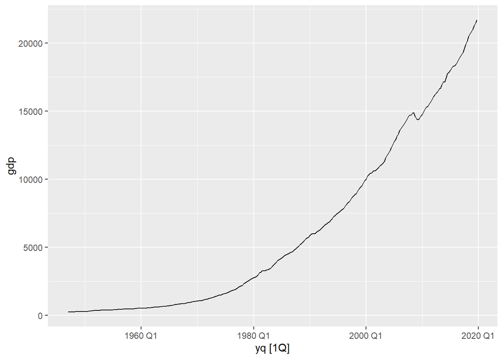

```r
# Change to quarterly data
ti <- as.yearqtr(ti, format="%Y-%m-%d")
ti <- yearquarter(ti)
US_QGDP$yq <- ti

# Change character to numeric vector
US_QGDP$gdp <- as.numeric(US_QGDP$gdp)

# Swap column order, change to tsibble object
US_QGDP <- select(US_QGDP, yq, gdp) %>%
    as_tsibble(index = yq)

autoplot(US_QGDP)
```

## Q1

### i) detecting stationarity of series visually

Obviously, from the gdp plot, we see a clear trend, so the series is not stationary.

### ii) Take the Log difference

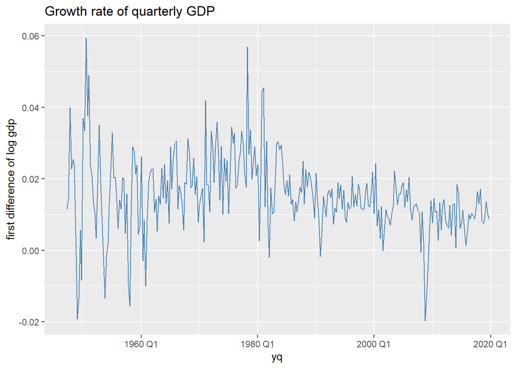

```r
plt.d.logUS_QGDP <- US_QGDP %>% transmute(
    'd.loggdp' = difference(log(gdp))
    ) %>%

    ggplot(aes(x=yq, y= d.loggdp)) +
    geom_line(col='steelblue') +
    labs( y = "first difference of log gdp", title = "Growth rate of quarterly GDP")

plt.d.logUS_QGDP
```

### iii) estimate AR(1) model for GDP growth rate

```r
#Save differenced log series
d.logUS_QGDP <- US_QGDP %>% transmute(
    'd.loggdp' = difference(log(gdp))
  )

# Fit AR(1) model
fit <- d.logUS_QGDP %>% drop_na() %>%
    model(AR(d.loggdp ~ order(1), na.rm=T))

report(fit)
```

```
## Series: d.loggdp
## Model: AR(1) w/ mean
##
## Coefficients:
##   constant     ar1
##     0.0077  0.4997
##
## sigma^2 estimated as 8.856e-05
## AIC = -79.66 AICc = -79.62   BIC = -72.31
```

```r
#forecast 1 quarter ahead
fit %>% forecast(h = 1)
```

```
## # A fable: 1 x 4 [1Q]
## # Key:     .model [1]
##   .model                                  yq          d.loggdp  .mean
##   <chr>                                <qtr>            <dist>  <dbl>
## 1 AR(d.loggdp ~ order(1), na.rm = T) 2020 Q1 N(0.012, 8.9e-05) 0.0121
```

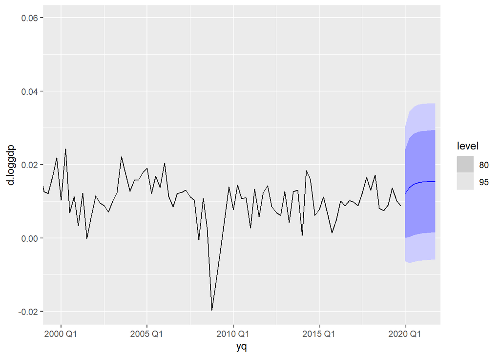

```r
#Plot forecasted path and distribution along with original data
forecast.1 <- fit %>% forecast() %>% autoplot(d.logUS_QGDP) +
    coord_x_date(xlim = c("2000-1-1" , "2021-1-1"))
forecast.1
```

### iv) Estimate AR(2) model for GDP Growth rate

```r
#Fit AR(2) model
fit2 <- d.logUS_QGDP %>% drop_na() %>%
    model(AR(d.loggdp ~ order(2), na.rm=T)
    )

report(fit2)
```

```
## Series: d.loggdp
## Model: AR(2) w/ mean
##
## Coefficients:
##   constant     ar1     ar2
##     0.0064  0.4138  0.1725
##
## sigma^2 estimated as 8.622e-05
## AIC = -85.46 AICc = -85.37   BIC = -74.44
```

```r
#Forecast 1 quarter ahead
fit2 %>% forecast(h = 1)
```

```
## # A fable: 1 x 4 [1Q]
## # Key:     .model [1]
##   .model                                  yq          d.loggdp  .mean
##   <chr>                                <qtr>            <dist>  <dbl>
## 1 AR(d.loggdp ~ order(2), na.rm = T) 2020 Q1 N(0.012, 8.6e-05) 0.0117
```

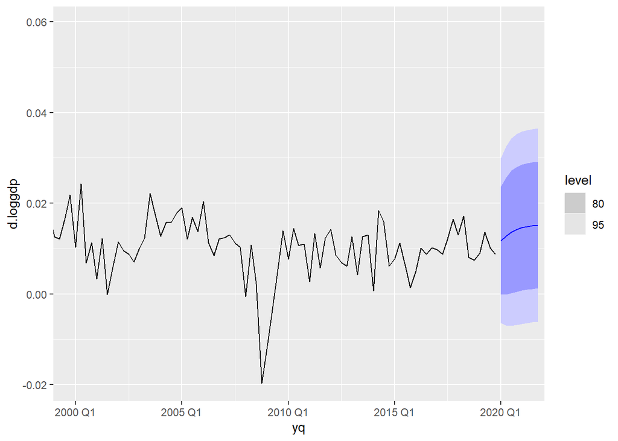

```r
#Plot forecasted path along original data
forecast.2 <- fit2 %>% forecast() %>% autoplot(d.logUS_QGDP) +
coord_x_date(xlim = c("2000-1-1" , "2021-1-1"))

forecast.2
```

# Assignment 2 - Dealing with volatility time series and and conducting residual analysis

```r
# Load Libraries
# library(haven)
# library(fpp3)
# library(fUnitRoots)
# library(tidyquant)
```

## Q1

### i) Make judgement on stationarity of vol time series

```r
# read data after setting to appropriate wd
#
vol = read_dta("c:/Users/idkup/OneDrive - The Chinese University of Hong Kong/Jay's coding/Data/ECON4120/vol.dta")

sum(is.na(vol))
```

```
## [1] 1
```

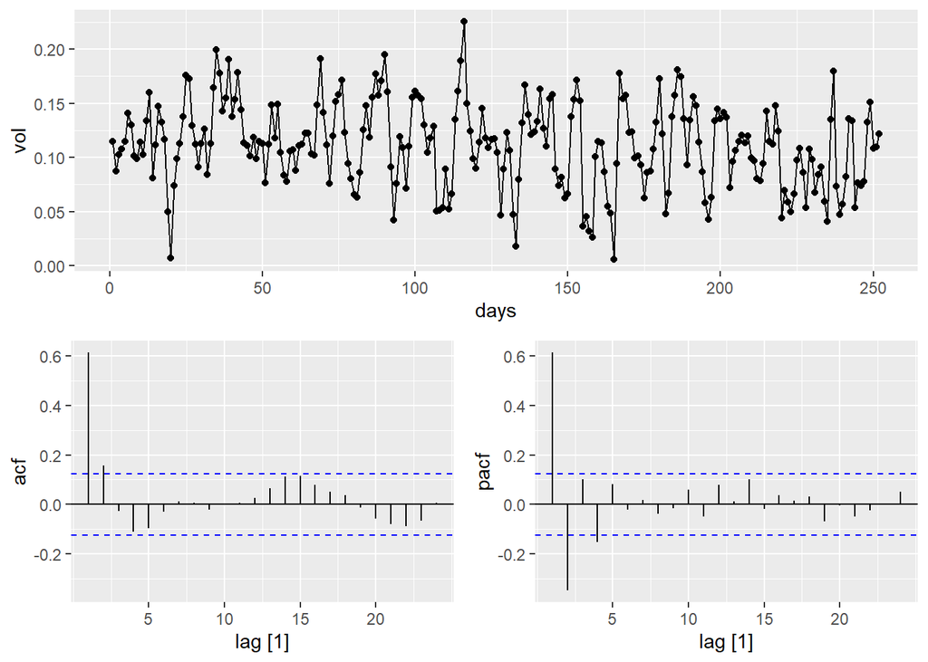

```r
vol <- drop_na(vol)

vol <- vol %>% as_tsibble(index=days)

vol %>%  gg_tsdisplay(vol, plot_type='partial')
```

Judging from visual inspection, it seems volatility time series is stationary. However, we conduct a unit-root test for statistical confirmation.

### ii) perform adf test

```r
fUnitRoots::unitrootTest(vol$vol)
```

```
##
## Title:
##  Augmented Dickey-Fuller Test
##
## Test Results:
##   PARAMETER:
##     Lag Order: 1
##   STATISTIC:
##     DF: -2.5121
##   P VALUE:
##     t: 0.0119
##     n: 0.2754
##
## Description:
##  Mon Oct 23 17:53:16 2023 by user: idkup
```

```r
fUnitRoots::adfTest(vol$vol)
```

```
##
## Title:
##  Augmented Dickey-Fuller Test
##
## Test Results:
##   PARAMETER:
##     Lag Order: 1
##   STATISTIC:
##     Dickey-Fuller: -2.5121
##   P VALUE:
##     0.01291
##
## Description:
##  Mon Oct 23 17:53:16 2023 by user: idkup
```

P-value is 0.01291, so we can reject null hypothesis (i.e., series has unit root, at 5% level)

### iii) fit ARMA models

Judging from acf and pacf, we could try: - ARMA(2,0) - ARMA(0,2) - ARMA(0,1) - ARMA(2,2) - ARMA(1,1)

```r
fit <- vol %>%
    model(arima200 = ARIMA(vol ~ pdq(2,0,0)),
        arima002 = ARIMA(vol ~ pdq(0,0,2)),
        arima202 = ARIMA(vol ~ pdq(2,0,2)),
        arima101 = ARIMA(vol ~ pdq(1,0,1))
    )

#Generate residuals of all four models
augment(fit) %>% select(-vol, -.fitted, -.resid) %>%
    pivot_wider(names_from = .model, values_from = .innov)
```

```
## # A tsibble: 252 x 5 [1]
##     days arima200 arima002  arima202 arima101
##    <dbl>    <dbl>    <dbl>     <dbl>    <dbl>
##  1     1  0.00258  0.00259  0.00254   0.00255
##  2     2 -0.0246  -0.0239  -0.0240   -0.0243
##  3     3  0.0124   0.0113   0.0122    0.0116
##  4     4 -0.00493 -0.00894 -0.00796  -0.00770
##  5     5  0.00340  0.00892  0.00815   0.00894
##  6     6  0.0255   0.0235   0.0231    0.0232
##  7     7 -0.00479 -0.00425 -0.00489  -0.00422
##  8     8 -0.0150  -0.0113  -0.0126   -0.0132
##  9     9  0.00186 -0.00194 -0.000771 -0.00200
## 10    10  0.00963  0.00669  0.00804   0.00765
## # ℹ 242 more rows
```

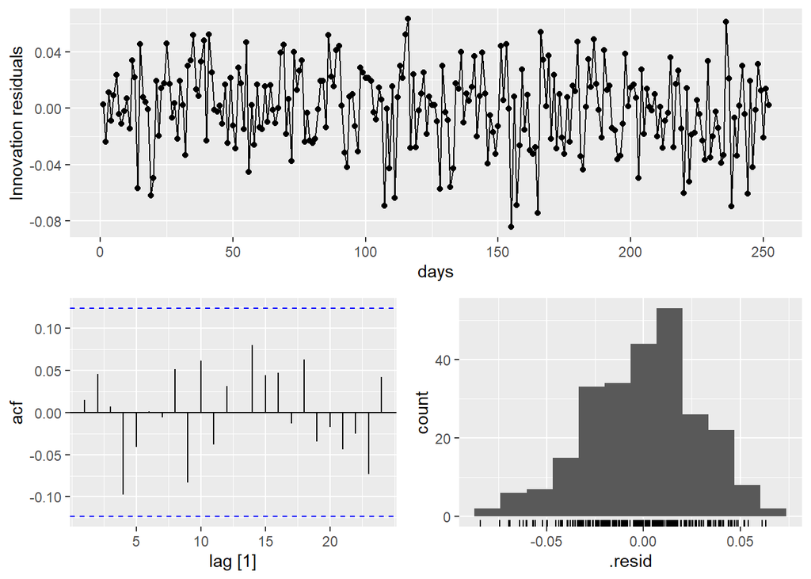

```r
# Residual Analysis using ljung-box test

fit %>% select(arima002) %>% gg_tsresiduals()
```

```r
augment(fit) %>% filter(.model == 'arima002') %>%
    features(.innov, ljung_box)
```

```
## # A tibble: 1 × 3
##   .model   lb_stat lb_pvalue
##   <chr>      <dbl>     <dbl>
## 1 arima002  0.0589     0.808
```

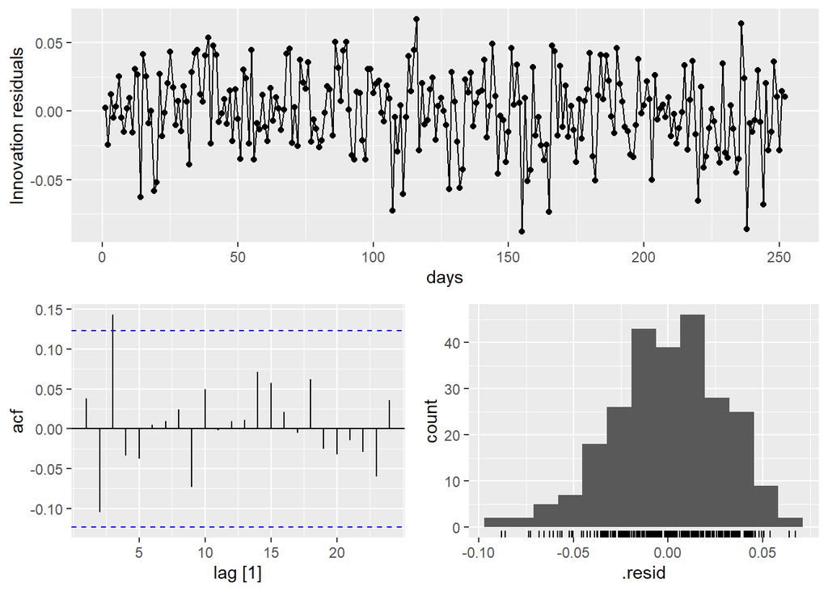

```r
fit %>% select(arima200) %>% gg_tsresiduals()
```

```r
augment(fit) %>% filter(.model == 'arima200') %>%
    features(.innov, ljung_box)
```

```
## # A tibble: 1 × 3
##   .model   lb_stat lb_pvalue
##   <chr>      <dbl>     <dbl>
## 1 arima200   0.375     0.540
```

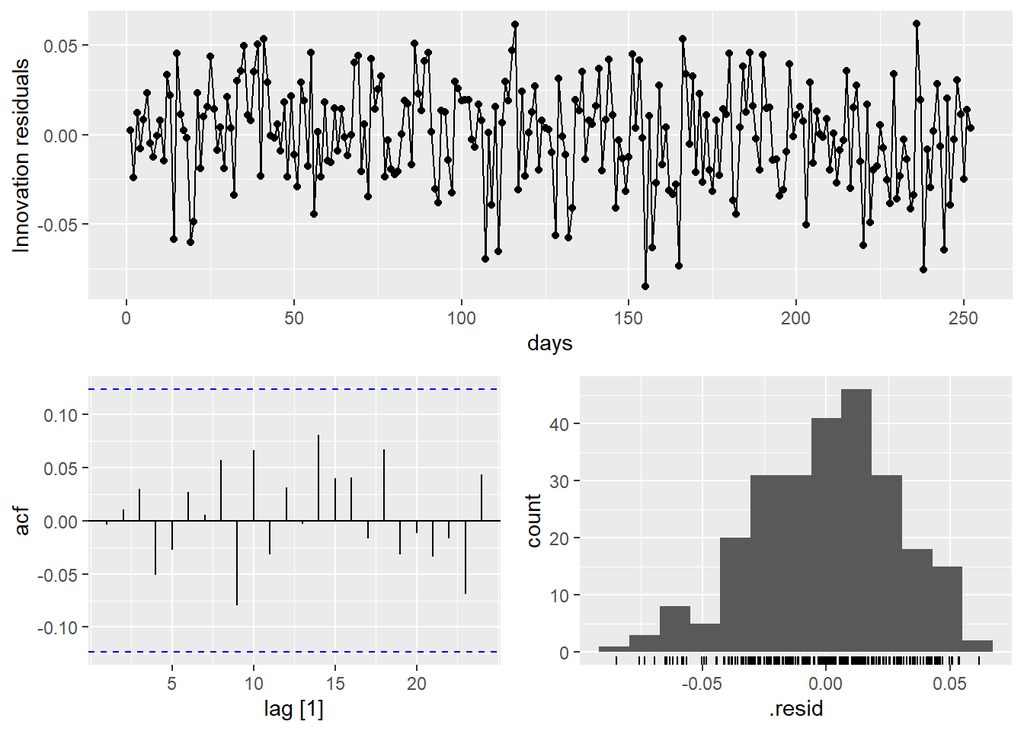

```r
fit %>% select(arima202) %>% gg_tsresiduals()
```

```r
augment(fit) %>% filter(.model == 'arima202') %>%
    features(.innov, ljung_box)
```

```
## # A tibble: 1 × 3
##   .model   lb_stat lb_pvalue
##   <chr>      <dbl>     <dbl>
## 1 arima202 0.00322     0.955
```

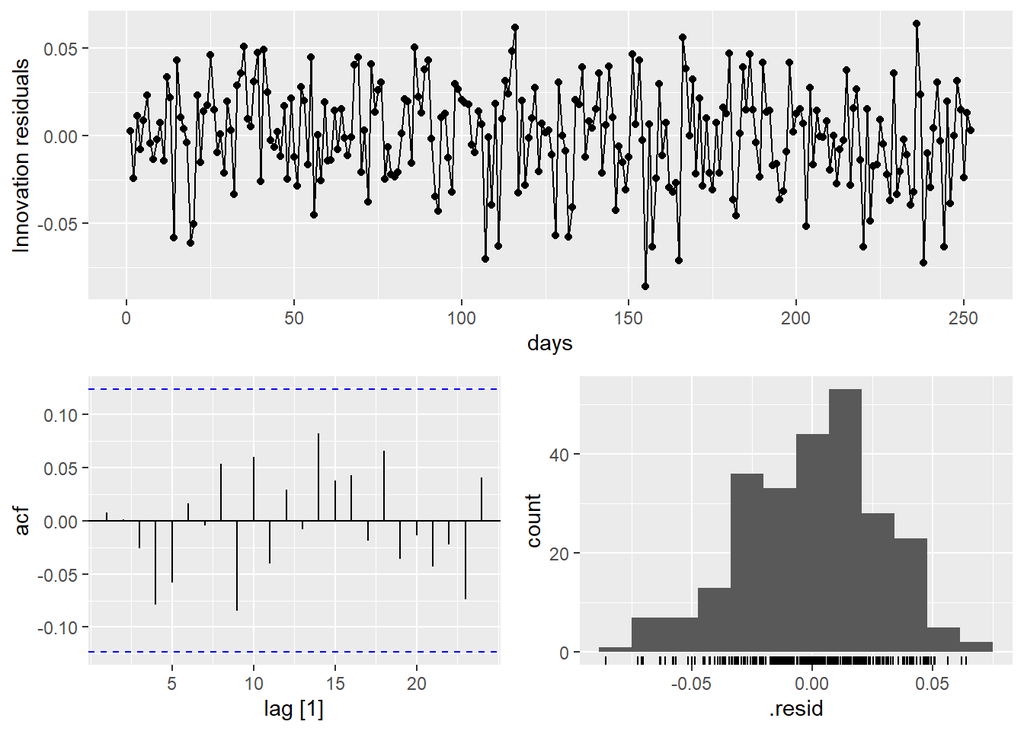

```r
fit %>% select(arima101) %>% gg_tsresiduals()
```

```r
augment(fit) %>% filter(.model == 'arima101') %>%
    features(.innov, ljung_box)
```

```
## # A tibble: 1 × 3
##   .model   lb_stat lb_pvalue
##   <chr>      <dbl>     <dbl>
## 1 arima101  0.0145     0.904
```

### iv) Generate ICs of models and choose based on ICs

```r
glance(fit)
```

```
## # A tibble: 4 × 8
##   .model     sigma2 log_lik    AIC   AICc    BIC ar_roots  ma_roots
##   <chr>       <dbl>   <dbl>  <dbl>  <dbl>  <dbl> <list>    <list>
## 1 arima200 0.000848    535. -1061. -1061. -1047. <cpl [2]> <cpl [0]>
## 2 arima002 0.000825    538. -1068. -1068. -1054. <cpl [0]> <cpl [2]>
## 3 arima202 0.000825    539. -1066. -1066. -1045. <cpl [2]> <cpl [2]>
## 4 arima101 0.000822    539. -1069. -1069. -1055. <cpl [1]> <cpl [1]>
```

**Based on ICs, ARIMA(1,0,1) seems the best model**.

### v) Make one step forecasts and plot them on the graph, showing the volatility series

```r
#Show one step forecasts ARIMA(1,0,1) model
fit %>% forecast(h=1) %>%
    filter(.model == 'arima101')
```

```
## # A fable: 1 x 4 [1]
## # Key:     .model [1]
##   .model    days              vol .mean
##   <chr>    <dbl>           <dist> <dbl>
## 1 arima101   253 N(0.12, 0.00082) 0.116
```

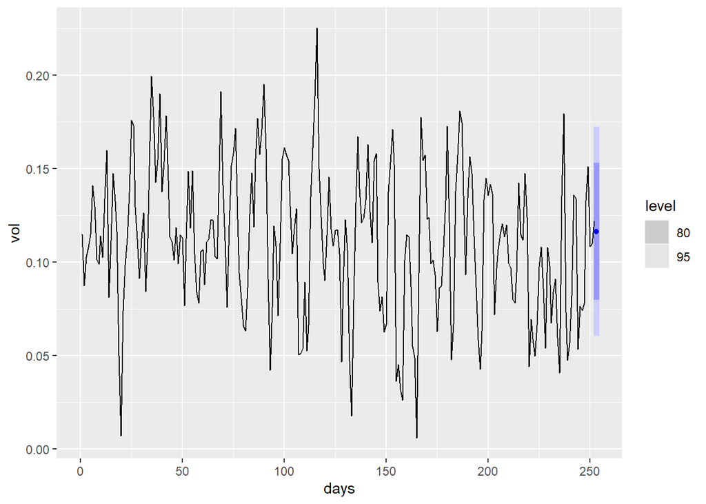

```r
# plot onestep forecast on vol time series
fit %>% forecast(h = 1) %>%
    filter(.model == 'arima101') %>%
    autoplot(vol)
```

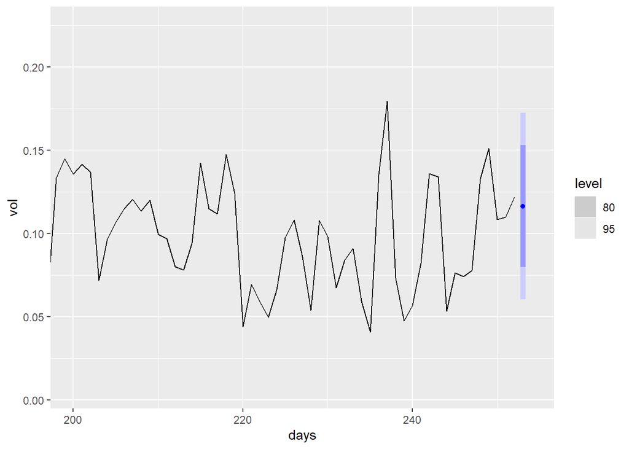

```r
# Zoom in on plot by letting start point equal to 200th day and ends at 254th day
fit %>% forecast(h=1) %>%
    filter(.model == 'arima101') %>%
    autoplot(vol) +
    coord_x_date(xlim = c( 200 , 254))
```

## Q2

### i) Inspect forex data and determine model of friction

```
## Plot variable not specified, automatically selected `.vars = forex`
```

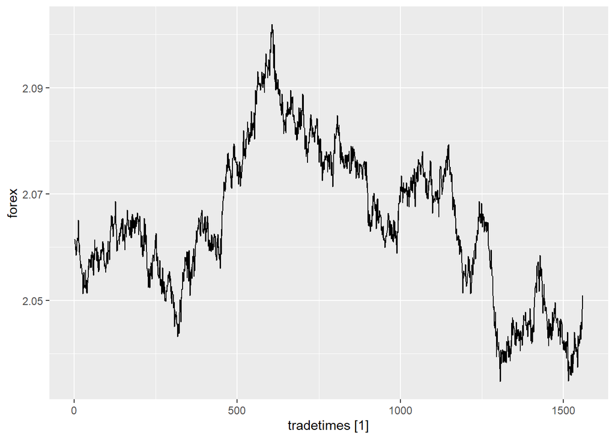

```r
# load data

forex <- read_dta("c:/Users/idkup/OneDrive - The Chinese University of Hong Kong/Jay's coding/Data/ECON4120/forex.dta")

forex <- as_tsibble(forex, index = tradetimes)

autoplot(forex)
```

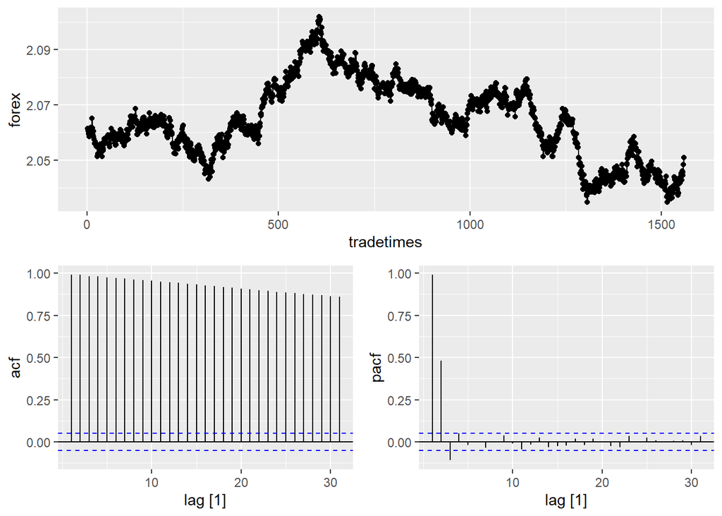

```r
# ACF and PACF
forex %>% gg_tsdisplay(forex, plot_type = "partial")
```

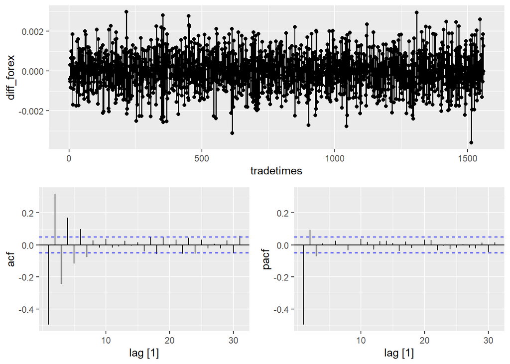

```r
# Take difference of logarithmic exchange rates to find log change (return)
forex %>%
    mutate(diff_forex = difference(log(forex))) %>%
    gg_tsdisplay(diff_forex, plot_type = "partial")
```

It seems as if log differenced series is stationary.

```r
# Fit ARMIA models

fit2 <- forex %>%
    mutate(diff_forex = difference(log(forex))) %>%
    model(
        arima100 = ARIMA(diff_forex ~ pdq(1,0,0)),
        arima300 = ARIMA(diff_forex ~ pdq(3,0,0)),
        stepwise = ARIMA(diff_forex ~ 0),
        search = ARIMA(diff_forex ~ 0, stepwise = FALSE)
    )
report(fit2)
```

```
## # A tibble: 4 × 8
##   .model        sigma2 log_lik     AIC    AICc     BIC ar_roots  ma_roots
##   <chr>          <dbl>   <dbl>   <dbl>   <dbl>   <dbl> <list>    <list>
## 1 arima100 0.000000675   8863. -17723. -17723. -17712. <cpl [1]> <cpl [0]>
## 2 arima300 0.000000667   8874. -17740. -17740. -17719. <cpl [3]> <cpl [0]>
## 3 stepwise 0.000000667   8874. -17740. -17740. -17719. <cpl [3]> <cpl [0]>
## 4 search   0.000000667   8874. -17740. -17740. -17719. <cpl [3]> <cpl [0]>
```